# DOCA and tidyverse

## Loading Data

We’ll be making extensive use of [tidyverse packages](https://www.tidyverse.org/packages/) in this course. These packages are designed with a shared set of rules in mind and so it can simplify a lot of complicated data analysis problems that would otherwise require you to write a lot of R code.

If you don’t have it already, you’ll want to start by installing the tidyverse packages:

```r
install.packages("tidyverse")
```

Remember that you’ll only need to install a package once, but you’ll need to run `library(packagename)` at the top of your script every time your restart R in order to use any functions from that package. The code below will load both the tidyverse core packages and also the haven package, which we will use to read in data sets from other coding languages.

```r
library(tidyverse)
library(haven)
```

Once you have the DOCA data downloaded, you’ll need to import it into R and assign it to a variable. Since this data set uses .dta format, we’ll read it in using the `read_dta` function from the haven package.

We’ll also run `doca<-as_factor(doca)` to convert some Stata formatted information into something that R can recognize.

```r
doca<-read_dta('final_data_v10.dta',
               encoding='latin1') # this option might fix issues for mac users
doca<-as_factor(doca)
```

If you’re using Rstudio, you should see `doca` pop up in the window at the top-right of your screen. If you click on the name, you can bring up a view of the data set. Alternatively, you can use the `slice_head` function to view the first few rows in the console.

```r
slice_head(doca, n = 10)
```

| coder | date | newsnm | rptmm | rptdd | rptyy | evmm | evdd | evyy | days | eventid | stories | title | followup | who | what | where | against | purpose | whysm | page | section | paragrph | staten | state1 | state2 | state3 | state4 | cityn | city1 | … |
| --- | --- | --- | --- | --- | --- | --- | --- | --- | --- | --- | --- | --- | --- | --- | --- | --- | --- | --- | --- | --- | --- | --- | --- | --- | --- | --- | --- | --- | --- | --- |
| LEAH MILLER | 2001-06-10 | NYT | 1 | 2 | 1960 | 1 | 1 | 1960 | 1 | 6001001 | 1 | VIRGINIA NEGROES RALLY | 0 | 2700 AFRICAN AMERICANS--DR KING WAS PRESENT | STAGED PROTEST MARCH ON STATE CAPITOL--RESOLUTION OF PROTEST WAS READ | RICHMOND, VA | GOVERNMENT AND SCHOOLS | PROTEST CLOSING OF SCHOOLS TO CIRCUMVENT A FEDERAL DESEGREGATION ORDER | COLLECTIVE, CLAIMS MADE, PUBLIC | 4 | 1 | 6 | 1 | VA |  |  |  | 1 | RICKMOND | … |
| LEAH MILLER | 2001-06-10 | NYT | 1 | 2 | 1960 | 1 | 1 | 1960 | 1 | 6001002 | 1 | AIRPORT IS SCENE OF NEGRO PROTEST | 0 | AFRICAN AMERICANS | 15 STAGED SIT-IN OF WHITE WAITING ROOM WHILE 250 WAITED OUTSIDE | GREENVILLE MUNICIPLE AIRPORT IN SOUTH CAROLINA | AIRPORT AND THE GOVERNMENT | PROTEST SEGREGATION | COLLECTIVE, CLAIMS MADE, PUBLIC | 4 | 1 | 5 | 1 | SC |  |  |  | 1 | GREENVILLE | … |
| LEAH MILLER | 2001-06-10 | NYT | 1 | 5 | 1960 | 1 | 4 | 1960 | 1 | 6001003 | 1 | 50% RISE IS URGED IN STATE SCHOOL AID | 0 | THE CITIZENS UNION | PRESS CONFERENCE ASKING FOR 50% INCREAS IN STATE AID TO CITIES | NEW YORK CITY | STATE | AID FOR SCHOOLS, DAY CARE CENTERS, ELECTION REFORM | COLLECTIVE, CLAIMS MADE, PUBLIC | 8 | 1 | 6 | 1 | NY |  |  |  | 1 | NEW YORK | … |
| LEAH MILLER | 2001-06-10 | NYT | 1 | 6 | 1960 | 1 | 5 | 1960 | 1 | 6001004 | 1 | ILLINOIS UNIT IN COURT | 0 | ANTI-INTEGRATION GROUP | SOUGHT A COURT ORDER ASKING FOR DATA ON ALLOCATION OF HOMES TO NEGROES AND A PETITION TO START CONDEMNATION PROCEEDINGS | CHICAGO | AFRICAN AMERICANS AND PROJECT DEVELOPMENT CORP | ANTI-INTEGRATION | COLLECTIVE, CLAIMS MADE, PUBLIC | 23 | 1 | 4 | 1 | IL |  |  |  | 1 | CHICAGO | … |
| LEAH MILLER | 2001-06-10 | NYT | 1 | 7 | 1960 | 1 | 5 | 1960 | 1 | 6001005 | 1 | DESECRATION IN PHILADELPHIA | 0 | UNKNOWN | PAINTED THREE SWASTIKAS ON SIDE OF BUILDING | CONGREGATION RODEPH SHALOM IN PHILADELPHIA | JEWISH COMMUNITY AND CHURCH | ANTI-SEMITISM | ETHNIC / RACIAL VIOLENCE | 3 | 1 | 1 | 1 | PA |  |  |  | 1 | PHILADELPHIA | … |
| LEAH MILLER | 2001-06-10 | NYT | 1 | 7 | 1960 | 1 | 6 | 1960 | 1 | 6001006 | 1 | CAPITOL SUBWAY MARKED | 0 | UNKNOWN | 2 SWASTIKAS MARKED WITH CRAYON ON SUBWAY WALL | DUPONT CIRCLE IN WASHINGTON DC | JEWISH COMMUNITY | ANTI-SEMITISM | ETHNIC / RACIAL VIOLENCE | 3 | 1 | 1 | 1 | DC |  |  |  | 1 | WASHINGTON | … |
| LEAH MILLER | 2001-06-10 | NYT | 1 | 7 | 1960 | 1 | 6 | 1960 | 1 | 6001007 | 1 | SWASTIKAS IN MAMARONECK | 0 | UNKNOWN | 4 SWASTIKAS PAINTED ON WALLS AND WINDOWS, ANTI-SEMITIC SIGN LEFT BY VANDALS | WESTCHEST JEWISH CENTER | JEWISH COMMUNITY | ANTI-SEMITISM | ETHNIC / RACIAL VIOLENCE | 3 | 1 | 3 | 1 | NY |  |  |  | 1 | MAMARONECK | … |
| LEAH MILLER | 2001-06-10 | NYT | 1 | 4 | 1960 | 1 | 3 | 1960 | 1 | 6001008 | 1 | POWELL SEES BIAS IN POLICY ARRESTS | 0 | 1000 PERSONS | RALLY WITH SPEECHES MADE BY SENATORS AND REPRESENTATIVES | ABYSSINIAN BAPTIST CHURCH IN HARLEM | STATE, POLICE | ANTI-POLICE HARRASSMENT AND TO PROMOTE CIVIL RIGHT OF AFRICAN AMERICANS | COLLECTIVE, CLAIMS MADE, PUBLIC | 9 | 1 | 16 | 1 | NY |  |  |  | 1 | NEW YORK | … |
| LEAH MILLER | 2001-06-10 | NYT | 1 | 2 | 1960 | 1 | 1 | 1960 | 1 | 6001009 | 2 | VICTORS AT DALLAS ACCUSE FOES OF DIRTY PLAY AND RACIAL SLURS | 0 | SYRACUSE AND TEXAS FOOTBALL PLAYERS | RACIAL SLURS FROM TEXAS PLAYER CAUSED BRAWL | DALLAS, TX | EACH OTHER | RACIAL CONFLICT | ETHNIC / RACIAL VIOLENCE | 8 | 1 | 22 | 1 | TX |  |  |  | 1 | DALLAS | … |
| LEAH MILLER | 2001-06-10 | NYT | 1 | 7 | 1960 | 1 | 6 | 1960 | 1 | 6001010 | 1 | CITY ACTION URGED TO COMBAT BIGOTS | 0 | COMMISSION ON INTERGROUP RELATIONS | ISSUED A PRESS STATEMENT | NEW YORK CITY | ANTI-SEMITIC ATTITUDES | URGING SCHOOLS , POLICE, COURTS, CHURCHS AND PARENTS TO HELP CORRECT BIAS IN CITY | COLLECTIVE, CLAIMS MADE, PUBLIC | 3 | 1 | 17 | 1 | NY |  |  |  | 1 | NEW YORK | … |

### Using the codebook

When browsing the data, you’ll probably notice that some columns are self-explanatory, but other columns are a little harder to parse: columns names like `particex` don’t have an obvious interpretation.

Data that we work with in this class will not always come with clear variable names or value labels, so you’ll need to consult the [codebook](https://web.stanford.edu/group/collectiveaction/cgi-bin/drupal/node/17) and [additional documentation](https://web.stanford.edu/group/collectiveaction/cgi-bin/drupal/node/3) for the data set.

#### Question 1

**Which column contains the year the event occurred? How would I access its values?**

```r
# Q1
```

## Using pipes

The `|>` operator (or sometimes `%>%`) is a way of making code a little more readable and less repetitive by “piping” data from one function to the next. For instance, if I wanted to find the earliest event in the DOCA data, I could use the `min` function like this:

```r
min(doca$evyy, na.rm=T)
```

```
[1] 1955
```

Or I could rewrite this statement by piping the data forward like this:

```r
doca$evyy|>min(na.rm=T)
```

```
[1] 1955
```

This might seem kind of pointless in the current example, but the real advantage becomes more clear when you’re doing a bunch of different things to a bit of data. For instance, if I wanted to calculate the proportion of violent and non-violent protest in 1980 I would need to do the following:

1. Get the subset of the data where `evyy` (event year) is 1980)
2. Select the `viold` column (which is `TRUE` if the protest was violent and `FALSE` otherwise
3. Create a frequency table using the `table` command
4. Convert the frequencies to proportions using `prop.table`

I could do all these steps in one line with a series of nested parentheses, but writing the code that way is hard to read:

```r
prop.table(table(subset(doca, evyy == 1980, select = viold)))
```

```
viold
        0         1
0.8536913 0.1463087
```

Here’s how I could rewrite that using pipes:

```r
doca|>
  subset(evyy==1980, select=viold)|>
  table()|>
  prop.table()
```

```
viold
        0         1
0.8536913 0.1463087
```

You’re not required to use this, and there’s never going to be a case where you can only write a particular piece of code by using a pipe. However you will see it come up a fair bit in code I share with the class and other written guides on using tidyverse packages, so at a bare minimum you want to know how to interpret it.

## Filtering

We’ll often want to remove rows that match a condition from a data set entirely. For instance: there’s a single protest even in the DOCA data set that takes place in 1955. There’s a reason for this in the coding rules, but in practice it makes for a lot of nonsensical plots, so we usually just want to remove it before doing anything.

The `subset` function is a way to do this in base R, but I’ll often use the `filter` function to accomplish the same thing (mostly out of habit). We can give filter a logical expression and it will keep only rows where that expression is `TRUE`

```r
# keep only rows that are after 1955
doca<-doca|>
  filter(evyy > 1955)

# now the minimum year should be 1960
min(doca$evyy, na.rm=T)
```

```
[1] 1960
```

Keep in mind that a filter removes rows from the data set, so you want to be careful that you’re not throwing away information you might want to use elsewhere in your analysis. If you just want to temporarily get a subset of some data, you can always just assign your results to a new variable:

```r
# create a new variable with only the 1980 results
doca_1980<-doca|>
  filter(evyy == 1980)

# check the number of rows remaining:
nrow(doca_1980)
```

```
[1] 746
```

#### Question 2

How would I create a data set containing only the events where a person was killed?

```r
#Q2
docadeaths<-doca|>
  filter(deaths == 1)
```

## Counting observations

Since many social science variables are categorical, many of our analyses will involve counting the number of observations with a particular value. We can use the `table` function to get counts of a particular category for some quick analysis, but we’ll also use the `dplyr` function `count` or `summarize` to get the same result.

### Using table

For instance, if we want to create a table with a count of events in each state, we could run:

```r
# count the number of events per state
state_tab<-table(doca$state1)

# View the results
state_tab
```

```
                   AK         AL         AR         AZ         CA         CO
       268         37        553         75         69       1354        119
        CT         DC         DE         FL         GA         HI         IA
       515       1825         31        507        639         37         77
        ID         IL         IN         KS         KY         LA         MA
        28        753        102         91         96        376        856
        MD         ME         MI         MN         MO         MS         MT
       220         55        387        113        149        495         25
        NC         ND         NE         NH         NJ         NM         NV
       317          9         32        102       1346         47         36
        NY         OH         OK         OR         PA         PR         RI
      8435        359         61         94        592         10         95
        SC         SD         TN         TX         UT         VA         VT
       189         37        260        330         50        228         47
        WA Washington         WI         WV         WY
       136          1        208         57         21
```

```r
sort(state_tab, decreasing=T)
```

```
        NY         DC         CA         NJ         MA         IL         GA
      8435       1825       1354       1346        856        753        639
        PA         AL         CT         FL         MS         MI         LA
       592        553        515        507        495        387        376
        OH         TX         NC                    TN         VA         MD
       359        330        317        268        260        228        220
        WI         SC         MO         WA         CO         MN         IN
       208        189        149        136        119        113        102
        NH         KY         RI         OR         KS         IA         AR
       102         96         95         94         91         77         75
        AZ         OK         WV         ME         UT         NM         VT
        69         61         57         55         50         47         47
        AK         HI         SD         NV         NE         DE         ID
        37         37         37         36         32         31         28
        MT         WY         PR         ND Washington
        25         21         10          9          1
```

And we can use the `[]` operator to get a subset of the data. This code translates as “sort the data from highest to lowest, and then show the 1st through the 10th value”:

```r
sorted_tab <- sort(state_tab, decreasing=T)

sorted_tab[1:10]
```

```
  NY   DC   CA   NJ   MA   IL   GA   PA   AL   CT
8435 1825 1354 1346  856  753  639  592  553  515
```

Finally, I can convert the raw frequencies to proportions by using the `prop.table` function

```r
prop.table(sorted_tab)[1:10]
```

```
        NY         DC         CA         NJ         MA         IL         GA
0.36752211 0.07951723 0.05899525 0.05864668 0.03729685 0.03280903 0.02784192
        PA         AL         CT
0.02579408 0.02409481 0.02243911
```

Why are there so many more New York events? Does this real differences in protest activity or is there some other explanation?

### Using count

The `table` function works for quick analyses, but we’ll often use the dplyr `count` function instead. There are some subtle differences in how these work that will matter in the future, but for now, just note that we can get the same basic output that we got in the last step like this:

```r
doca|>
  # count the number of events by state and sort
  count(state1, sort=T)|>
  # show the top 10 rows
  slice_head(n=10)
```

| state1 | n |
| --- | --- |
| NY | 8435 |
| DC | 1825 |
| CA | 1354 |
| NJ | 1346 |
| MA | 856 |
| IL | 753 |
| GA | 639 |
| PA | 592 |
| AL | 553 |
| CT | 515 |

To calculate a proportion, I’ll need to divide `n` (the count of events per state) by the total number of events (the sum of `n`). I can use `mutate` to add a new column to a data set:

```r
state_proportions <- doca|>
  # count the number of events by state and sort
  count(state1, sort=T)|>
  # use mutate to add a new column
  mutate(proportion = n/sum(n))
```

#### Question 3

**How would I calculate the number of events per year using the count function? How would I calculate this for violent protests only?**

```r
#
```

## Making comparisons

When making inferences, we often need to make a comparison across one or more groups. For instance, if someone argued that “protests where counter demonstrators were present were more likely to become violent compared to protests without them”, then I would want to:

1. count the number of events with and without counter demonstrators
2. calculate the proportion of events in each group that were violent vs. non-violent.

We can easily add another variable to the count function like this (and we can use the `drop_na` function to remove missing data from our result set)

```r
vc_count<-doca|>
  count(counterd, viold)|>
  # remove rows with missing data:
  drop_na()


vc_count
```

| counterd | viold | n |
| --- | --- | --- |
| 0 | 0 | 18548 |
| 0 | 1 | 3187 |
| 1 | 0 | 903 |
| 1 | 1 | 290 |

… but how do we accomplish step 2 and calculate the proportions within each group? The code we used earlier doesn’t quite give us what we want because it divides each count by the total number of protest events. But we actually want the proportion of violent protests among protests with counter-demonstrators and those without.

```r
vc_count|>
  # count the number of events by state and sort
  # use mutate to add a new column
  mutate(proportion = n/sum(n))
```

| counterd | viold | n | proportion |
| --- | --- | --- | --- |
| 0 | 0 | 18548 | 0.80896720 |
| 0 | 1 | 3187 | 0.13900035 |
| 1 | 0 | 903 | 0.03938416 |
| 1 | 1 | 290 | 0.01264829 |

To do get this, we can use the `group_by` function to group rows together based on a characteristic. On its own, `group_by` doesn’t do much, but when we use it with `mutate`, we get a different result:

```r
proportion_by_group<-vc_count|>
  group_by(counterd)|>
  mutate(proportion = n /sum(n))

proportion_by_group
```

| counterd | viold | n | proportion |
| --- | --- | --- | --- |
| 0 | 0 | 18548 | 0.8533701 |
| 0 | 1 | 3187 | 0.1466299 |
| 1 | 0 | 903 | 0.7569153 |
| 1 | 1 | 290 | 0.2430847 |

Based on these results, we should be able to tell whether events with counter-demonstrators were more likely to turn violent.

#### Question 4

`propdam` is a dummy variable that indicates whether property damage occurred at an event. `smonamed` is a dummy variable that indicates whether a social movement organization was involved in the event. Is property damage more or less likely at events where a social movement organization was involved?

```r
#
```

## Renaming a factor

Most of the variables in this data set are given numeric codes that don’t make sense without consulting the codebook. This is fine for quick analysis, but when we’re presenting data, we may want to assign descriptive labels instead of using the numeric code. We can use the `case_when` statement to create new variables based on conditions.

The basic syntax here will be `case_when(variable == somevalue ~ "label")` . Which you can interpret as “if the statement is true, then assign this label.

Here’s an example of how we could do this to make the violence variable have a more useful label:

```r
doca<-doca|>
  mutate(violence = case_when(viold ==1 ~ "violence used",
                              viold == 0 ~ "no violence used"
                              ))

doca|>
  count(violence)|>
  drop_na()
```

| violence | n |
| --- | --- |
| no violence used | 19456 |
| violence used | 3481 |

#### Question 5

**How would I recode the counter demonstrators variable to have a more descriptive label?**

```r
# Q5
```

## Plotting a result

You can use `ggplot` to create graphics from the data we’ve assembled here.

We’ll get more into the mechanics of using `ggplot` in a later class, but just to get a basic sense of how this will work, here’s an example of how you could plot the number of events by year:

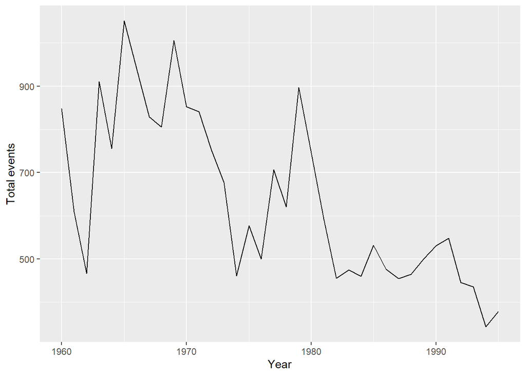

```r
yearly_events<-doca|>
  count(evyy)

# date, aes(x=, y=) and then add geometry:
ggplot(yearly_events, aes(x=evyy, y=n)) +
  geom_line() +
  xlab("Year") +
  ylab("Total events")
```

The advantages of ggplot will become more apparent when we start doing things like plotting multiple variables in the same plot. Here’s an example of plotting violent and non-violent events separately:

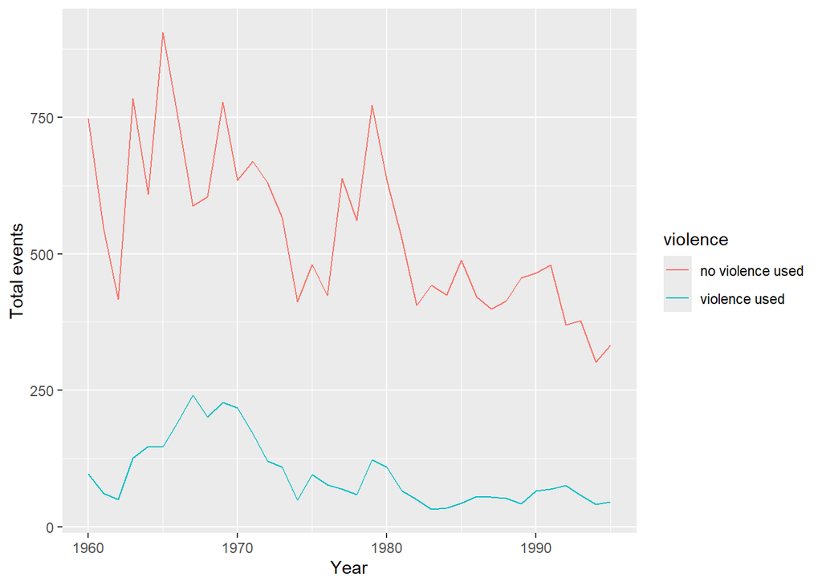

```r
yearly_events<-doca|>
  count(evyy, violence)|>
  drop_na()

# date, aes(x=, y=) and then add geometry:
ggplot(yearly_events, aes(x=evyy, y=n, color=violence)) +
  geom_line() +
  xlab("Year") +
  ylab("Total events")
```

# function reference

This is a list of functions used in this document, along with some additional examples of how they work. If you’re looking for even more detail, the best place to look is in the help file for that function, which you can access by running `help(function name here)` in the R console.

Most of these functions come from the `dplyr` package, which has some [very nice online documentation](https://dplyr.tidyverse.org/) as well.

## slice_*

`slice_head`, (and `slice_tail`, `slice_min`, and `slice_max`) will extract a subset of a data set. Slice head just gets the first `n` rows:

```r
doca|>
  slice_head(n=5)
```

| coder | date | newsnm | rptmm | rptdd | rptyy | evmm | evdd | evyy | days | eventid | stories | title | followup | who | what | where | against | purpose | whysm | page | section | paragrph | staten | state1 | state2 | state3 | state4 | cityn | city1 | … |
| --- | --- | --- | --- | --- | --- | --- | --- | --- | --- | --- | --- | --- | --- | --- | --- | --- | --- | --- | --- | --- | --- | --- | --- | --- | --- | --- | --- | --- | --- | --- |
| LEAH MILLER | 2001-06-10 | NYT | 1 | 2 | 1960 | 1 | 1 | 1960 | 1 | 6001001 | 1 | VIRGINIA NEGROES RALLY | 0 | 2700 AFRICAN AMERICANS--DR KING WAS PRESENT | STAGED PROTEST MARCH ON STATE CAPITOL--RESOLUTION OF PROTEST WAS READ | RICHMOND, VA | GOVERNMENT AND SCHOOLS | PROTEST CLOSING OF SCHOOLS TO CIRCUMVENT A FEDERAL DESEGREGATION ORDER | COLLECTIVE, CLAIMS MADE, PUBLIC | 4 | 1 | 6 | 1 | VA |  |  |  | 1 | RICKMOND | … |
| LEAH MILLER | 2001-06-10 | NYT | 1 | 2 | 1960 | 1 | 1 | 1960 | 1 | 6001002 | 1 | AIRPORT IS SCENE OF NEGRO PROTEST | 0 | AFRICAN AMERICANS | 15 STAGED SIT-IN OF WHITE WAITING ROOM WHILE 250 WAITED OUTSIDE | GREENVILLE MUNICIPLE AIRPORT IN SOUTH CAROLINA | AIRPORT AND THE GOVERNMENT | PROTEST SEGREGATION | COLLECTIVE, CLAIMS MADE, PUBLIC | 4 | 1 | 5 | 1 | SC |  |  |  | 1 | GREENVILLE | … |
| LEAH MILLER | 2001-06-10 | NYT | 1 | 5 | 1960 | 1 | 4 | 1960 | 1 | 6001003 | 1 | 50% RISE IS URGED IN STATE SCHOOL AID | 0 | THE CITIZENS UNION | PRESS CONFERENCE ASKING FOR 50% INCREAS IN STATE AID TO CITIES | NEW YORK CITY | STATE | AID FOR SCHOOLS, DAY CARE CENTERS, ELECTION REFORM | COLLECTIVE, CLAIMS MADE, PUBLIC | 8 | 1 | 6 | 1 | NY |  |  |  | 1 | NEW YORK | … |
| LEAH MILLER | 2001-06-10 | NYT | 1 | 6 | 1960 | 1 | 5 | 1960 | 1 | 6001004 | 1 | ILLINOIS UNIT IN COURT | 0 | ANTI-INTEGRATION GROUP | SOUGHT A COURT ORDER ASKING FOR DATA ON ALLOCATION OF HOMES TO NEGROES AND A PETITION TO START CONDEMNATION PROCEEDINGS | CHICAGO | AFRICAN AMERICANS AND PROJECT DEVELOPMENT CORP | ANTI-INTEGRATION | COLLECTIVE, CLAIMS MADE, PUBLIC | 23 | 1 | 4 | 1 | IL |  |  |  | 1 | CHICAGO | … |
| LEAH MILLER | 2001-06-10 | NYT | 1 | 7 | 1960 | 1 | 5 | 1960 | 1 | 6001005 | 1 | DESECRATION IN PHILADELPHIA | 0 | UNKNOWN | PAINTED THREE SWASTIKAS ON SIDE OF BUILDING | CONGREGATION RODEPH SHALOM IN PHILADELPHIA | JEWISH COMMUNITY AND CHURCH | ANTI-SEMITISM | ETHNIC / RACIAL VIOLENCE | 3 | 1 | 1 | 1 | PA |  |  |  | 1 | PHILADELPHIA | … |

## drop_na

`drop_na` will remove any `NA` values from the data set.

If you run `drop_na` without adding any variable names in parentheses, you will drop rows that have `NA` in ANY column:

```r
# drop ALL rows with missing data
doca_no_na <-doca|>
  drop_na()

# all rows have at least *SOME* missing data, so we lose everything here:
nrow(doca_no_na)
```

```
[1] 0
```

However, you can specify which variables you want to consider when removing data by adding them as arguments to `drop_na`. So if I wanted to drop only rows where the `act1` variable was missing, I could run:

```r
doca_act1<-doca|>
  drop_na(act1)

nrow(doca_act1)
```

```
[1] 22358
```

## |> (pipes)

`|>` or the “pipe operator” will take data from the left hand side and “pipe” it to a function on the right hand side. For instance:

```r
nrow(doca)
```

```
[1] 22951
```

…can be expressed as:

```r
doca|>nrow()
```

```
[1] 22951
```

## filter

`filter` will take a logical expression and return rows where that expression evaluates as `TRUE`

```r
doca|>
  filter(eventid == '6001009')
```

| coder | date | newsnm | rptmm | rptdd | rptyy | evmm | evdd | evyy | days | eventid | stories | title | followup | who | what | where | against | purpose | whysm | page | section | paragrph | staten | state1 | state2 | state3 | state4 | cityn | city1 | … |
| --- | --- | --- | --- | --- | --- | --- | --- | --- | --- | --- | --- | --- | --- | --- | --- | --- | --- | --- | --- | --- | --- | --- | --- | --- | --- | --- | --- | --- | --- | --- |
| LEAH MILLER | 2001-06-10 | NYT | 1 | 2 | 1960 | 1 | 1 | 1960 | 1 | 6001009 | 2 | VICTORS AT DALLAS ACCUSE FOES OF DIRTY PLAY AND RACIAL SLURS | 0 | SYRACUSE AND TEXAS FOOTBALL PLAYERS | RACIAL SLURS FROM TEXAS PLAYER CAUSED BRAWL | DALLAS, TX | EACH OTHER | RACIAL CONFLICT | ETHNIC / RACIAL VIOLENCE | 8 | 1 | 22 | 1 | TX |  |  |  | 1 | DALLAS | … |

Note that you’ll occasionally see `%>%` in place of `|>`, usually in older R code. This functions more-or-less the same way that `|>` does.

```r
doca%>%nrow()
```

```
[1] 22951
```

## count

`count` will count the number of rows based on one or more groups. (this works very similarly to `table` but it returns a `tibble` object).

```r
# counting violent events
doca|>
  count(viold)
```

| viold | n |
| --- | --- |
| 0 | 19456 |
| 1 | 3481 |
| NA | 14 |

```r
doca|>
  count(viold, sort=TRUE)
```

| viold | n |
| --- | --- |
| 0 | 19456 |
| 1 | 3481 |
| NA | 14 |

I can count on data on multiple dimensions as well. This code would give me the count of all unique combinations of the `viold` and `counterd` variables.

```r
doca|>
  count(viold,counterd)
```

| viold | counterd | n |
| --- | --- | --- |
| 0 | 0 | 18548 |
| 0 | 1 | 903 |
| 0 | NA | 5 |
| 1 | 0 | 3187 |
| 1 | 1 | 290 |
| 1 | NA | 4 |
| NA | 0 | 13 |
| NA | NA | 1 |

By default, count will also include counts of the `NA` categories, but we can remove these with the `drop_na` function.

## arrange

```r
doca|>
  # sort from highest to lowest
  arrange(-evyy)|>
  # take the top 10 rows
  slice_head(n=10)
```

| coder | date | newsnm | rptmm | rptdd | rptyy | evmm | evdd | evyy | days | eventid | stories | title | followup | who | what | where | against | purpose | whysm | page | section | paragrph | staten | state1 | state2 | state3 | state4 | cityn | city1 | … |
| --- | --- | --- | --- | --- | --- | --- | --- | --- | --- | --- | --- | --- | --- | --- | --- | --- | --- | --- | --- | --- | --- | --- | --- | --- | --- | --- | --- | --- | --- | --- |
| H MACIAS | 2001-08-07 | NYT | 1 | 2 | 1995 | 1 | 1 | 1995 | 1 | 9501002 | 1 | AUTHORITIES SEEKING MOTIVE FOR ATTACKS AT ABORTION CLINICS | 0 | 8 OPPONENTS OF ABORTION | PROTESTED OUTSIDE OF A JAIL | NORFOLK, VA |  | IN ORDER TO SUPPORT JOHN C. SALVI, WHO KILLED PEOPLE AT ABORTION CLINICS | COLLECTIVE, CLAIMS MADE, PUBLIC | 1 | A | 21 | 1 | VA |  |  |  | 1 | NORFOLK | … |
| H MACIAS | 2002-07-01 | NYT | 1 | 10 | 1995 | 1 | NA | 1995 | 1 | 9501012 | 1 | THREATS AT 4 ABORTION CLINICS | 0 | UNKNOWN | POSTED THREATENING SIGNS | 4 ABORTION CLINICS ON LONG ISLAND | THE CLINICS, ITS CLIENTS | TO DISCOURAGE THEIR USE | COLLECTIVE, CLAIMS MADE, PUBLIC | 12 | A | 10 | 1 | NY |  |  |  | 1 | LONG ISLAND | … |
| H MACIAS | 2002-07-01 | NYT | 1 | 11 | 1995 | 1 | 7 | 1995 | 1 | 9501014 | 1 | "VIGILANTE" ATTACK IN NEW JERSEY IS LINKED TO SEX OFFENDERS LAW | 0 | 2 MEN | ATTACKED A MAN | NEW JERSEY | A PERSON THEY THOUGHT WAS A SEX OFFENDER | TO EXPRESS POSITION ON CHILD ABUSE | COLLECTIVE, CLAIMS MADE, PUBLIC | 1 | A | 24 | 1 | NJ |  |  |  | 1 | PHILLIPSBURG | … |
| H MACIAS | 2002-07-01 | NYT | 1 | 13 | 1995 | 1 | 9 | 1995 | 1 | 9501018 | 1 | ANTI-ABORTION CLINIC RECEIVES A THREAT | 0 | UNKNOWN ANTI-ABORTIONISTS | LEFT A THREATENING NOTE | LONG ISLAN, AAA PREGNANCY OPTIONS | THE CENTER, ITS CLIENTS | TO OPPOSE ABORTION | COLLECTIVE, CLAIMS MADE, PUBLIC | 5 | B | 4 | 1 | NY |  |  |  | 1 | LONG ISLAND | … |
| H MACIA | 2002-07-01 | NYT | 1 | 15 | 1995 | 1 | 12 | 1995 | 1 | 9501022 | 1 | ENVIRONMENTAL GROUPS PROTEST PLAN TO MIN NEAR YELLOWSTONE | 0 | TWO ENVIRONMENTAL GROUPS | FILED A PETITION WITH THE SECRETARY OF THE INTERIOR | WASHINGTON, D.C. | CROWN BUTTE MINES INC. | TO BLOCK ITS ACQUISITION OF FEDERAL LAND | COLLECTIVE, CLAIMS MADE, PUBLIC | 23 | A | 8 | 1 | DC |  |  |  | 1 | WASHINGTON | … |
| H MACIAS | 2002-07-01 | NYT | 1 | 16 | 1995 | 1 | 15 | 1995 | 1 | 9501023 | 1 | MINISTERS RAISE VOICES IN FACE OF THE DEATH PENALTY | 0 | BLACK MINISTERS | DELIVERED SERMONS AGAINST THE DEATH PENALTY | NEW YORK | PENDING LEGISLATION | TO OPPOSE DEATH PENALTY | COLLECTIVE, CLAIMS MADE, PUBLIC | 1 | B | 14 | 1 | NY |  |  |  | 1 | NEW YORK | … |
| H MACIAS | 2002-07-01 | NYT | 1 | 17 | 1995 | 1 | 16 | 1995 | 1 | 9501025 | 1 | PROTESTERS DENOUNCE POLICE OVER CHOKING DEATH | 0 | 250 DEMONSTRATORS | DEMONSTRATED | THE STATE SUPREME COURT, NEW YORK | POLICE OFFICERS | TO DEMAND THE INDICTMENT OF OFFICERS | COLLECTIVE, CLAIMS MADE, PUBLIC | 3 | 2 | 1 | 1 | NY |  |  |  | 1 | NEW YORK | … |
| H MACIAS | 2002-07-01 | NYT | 1 | 17 | 1995 | 1 | 16 | 1995 | 1 | 9501026 | 1 | AT AN ATLANTA CELEBRATION: HOPE, RESOLVE AND MEMORIES | 0 | 400 PEOPLE | GATHERED | EBENEZER BAPTIST CHURCH |  | TO COMMEMORATE MARTIN LUTHER KING JRS BIRTHDAY | COLLECTIVE, CLAIMS MADE, PUBLIC | 4 | B | 11 | 1 | GA |  |  |  | 1 | ATLANTA | … |
| H MACIAS | 2002-07-01 | NYT | 1 | 17 | 1995 | 1 | 16 | 1995 | 1 | 9501027 | 1 | PREACHERS AND PLAIN FOLK HONOR DR. KING | 0 | 1000 PEOPLE | ATTENDED A SERMON | NEW YORK, CONVENT AVENUE BAPTIST CHURCH |  | TO COMMEMORATE MARTIN LUTHER KING JRS BIRTHDAY, LIFE | COLLECTIVE, CLAIMS MADE, PUBLIC | 4 | B | 14 | 1 | NY |  |  |  | 1 | NEW YORK | … |
| H MACIAS | 2002-07-01 | NYT | 1 | 20 | 1995 | 1 | NA | 1995 | 1 | 9501028 | 1 | COURT IS ASKED TO ORDER AUDIT OF NAACP | 0 | 7 MEMBERS OF THE NAACP | FILED A PETITION WITH THE FEERAL DISTRICT COURT IN BALTIMORE | BALTIMORE | NAACPS BOARD CHAIRMAN | TO INVESTIGATE CORRUPTION | COLLECTIVE, CLAIMS MADE, PUBLIC | 18 | A | 8 | 1 | MD |  |  |  | 1 | BALTIMORE | … |

## mutate

`mutate` will add a new column to a data set. We used it in a prior example to add a total or a proportion to the data set returned from the `count` function:

```r
doca|>
  count(state1)|>
  mutate(total_events = sum(n))
```

| state1 | n | total_events |
| --- | --- | --- |
|  | 268 | 22951 |
| AK | 37 | 22951 |
| AL | 553 | 22951 |
| AR | 75 | 22951 |
| AZ | 69 | 22951 |
| CA | 1354 | 22951 |
| CO | 119 | 22951 |
| CT | 515 | 22951 |
| DC | 1825 | 22951 |
| DE | 31 | 22951 |

[output cut: 44 more lines]

## group_by

`group_by` is used to create a grouped data frame. On its own, this doesn’t do much, but functions like `mutate` and `slice_head` and `summarize` will allow us to do calculations over specified groups instead of operating on the entire data set.

For example `slice_head` will ordinarily give us the first `n` rows from the data set, but if I use `slice_head` with group by, **I’ll get the first `n` rows from each group:**

```r
# get the first listed event in each year:
doca|>
  group_by(evyy)|>
  slice_head(n=1)
```

| coder | date | newsnm | rptmm | rptdd | rptyy | evmm | evdd | evyy | days | eventid | stories | title | followup | who | what | where | against | purpose | whysm | page | section | paragrph | staten | state1 | state2 | state3 | state4 | cityn | city1 | … |
| --- | --- | --- | --- | --- | --- | --- | --- | --- | --- | --- | --- | --- | --- | --- | --- | --- | --- | --- | --- | --- | --- | --- | --- | --- | --- | --- | --- | --- | --- | --- |
| LEAH MILLER | 2001-06-10 | NYT | 1 | 2 | 1960 | 1 | 1 | 1960 | 1 | 6001001 | 1 | VIRGINIA NEGROES RALLY | 0 | 2700 AFRICAN AMERICANS--DR KING WAS PRESENT | STAGED PROTEST MARCH ON STATE CAPITOL--RESOLUTION OF PROTEST WAS READ | RICHMOND, VA | GOVERNMENT AND SCHOOLS | PROTEST CLOSING OF SCHOOLS TO CIRCUMVENT A FEDERAL DESEGREGATION ORDER | COLLECTIVE, CLAIMS MADE, PUBLIC | 4 | 1 | 6 | 1 | VA |  |  |  | 1 | RICKMOND | … |
| AMY MEYERTHOLEN | 2001-01-09 | NYT | 1 | 3 | 1961 | 1 | 2 | 1961 | 1 | 6101003 | 1 | DEATH PENALTY PROTESTED | 0 | 2 PACIFISTS | HELD SIT-IN | OUTSIDE STATE CAPITAL | STATE GOVT. | TO OPPOSE NEW DEATH PENALTY LAWS | COLLECTIVE, CLAIMS MADE, PUBLIC | 16 | 1 | 1 | 1 | CA |  |  |  | 1 | SACRAMENTO | … |
| AMY MEYERTHOLEN | 2000-10-04 | NYT | 1 | 4 | 1962 | 1 | 2 | 1962 | 14 | 6201001 | 3 | CHICAGO SIT-IN RESUMES | 0 | MAINLY BLACK PARENTS AND CHILDREN | THEY STAGED A SIT-IN AND A STUDY-IN | BURNSIDE ELEMENTARY SCHOOL | THE SCHOOL | PROTEST SEGREGATED TRANSFER | COLLECTIVE, CLAIMS MADE, PUBLIC | 26 | 1 | 4 | 1 | IL |  |  |  | 1 | CHICAGO | … |
| SEAN CUNNINGHAM | 2000-12-13 | NYT | 12 | 2 | 1963 | 12 | 1 | 1963 | 1 | 6212005 | 1 | FEDERAL COPYRIGHTS ASSAILED BY EDITORS | 0 | GROUP OF EDITORS, LAWYERS, AND EDUCATORS | CIRCULATED STATEMENT REGARDING COPYRIGHT RESTRICTIONS ON DOCUMENTS AND PUBLICATIONS | WASHINGTON, D.C. | THE STATE | TO DISSUADE THE USE OF THE AFOREMENTIONED COPYRIGHT RESTRICTIONS | COLLECTIVE, CLAIMS MADE, PUBLIC | 88 | 1 | 6 | 1 | DC |  |  |  | 1 | WASHINGTON | … |
| MARVIN RUTH | 2000-09-14 | NYT | 6 | 13 | 1964 | 6 | 12 | 1964 | 1 | 6306090 | 1 | MARCHING NEGROES CHANT "FREEDOM" IN SAVANNAH | 0 | BLACK DEMONSTRATORS | MARCHED | SAVANNAH, GA | BUSINESSES AND CITY GOVERNMENT | PROTEST SEGREGATION | COLLECTIVE, CLAIMS MADE, PUBLIC | 15 | 1 | 12 | 1 | GA |  |  |  | 1 | SAVANNAH | … |
| MARVIN RUTH | 2000-07-12 | NYT | 10 | 14 | 1965 | 10 | 14 | 1965 | 1 | 6410008 | 1 | 6 RIGHTS GROUPS DENOUNCE GROSS | 0 | CIVIL RIGHTS GROUPS | ISSUED PRESS STATEMENT | NEW YORK | SUPERINTENDENT OF SCHOOLS GROSS AND THE BOARD OF EDUCATION | PUSH FOR QUICKER RESOLUTION OF SCHOOL INTEGRATION PROPOSALS | COLLECTIVE, CLAIMS MADE, PUBLIC | 1 | 1 | 28 | 1 | NY |  |  |  | 0 |  | … |
| MIKE MULCAHY |  | NYT | 1 | 2 | 1966 | 1 | 1 | 1966 | 1 | 6601003 | 1 | 300 in protest vigil here | 0 | peace protesters and smo | peace vigil | 49th st and rockefeller plaza | us govt | demand peace | COLLECTIVE, CLAIMS MADE, PUBLIC | 43 | 1 | 1 | 1 | NY |  |  |  | 1 | NEW YORK | … |
| TRACI ANDES |  | NYT | 1 | 3 | 1967 | 1 | 2 | 1967 | 1 | 6701001 | 1 | NEGRO MINISTERS DENOUNCE EFFORTS TO OUTST POWELL | 0 | BLACK CHURCHES | PETITION OPPOSING POLITICAL REPRESENTATIVE WHO WAS UNSEATED | NEW YORK CITY | FEDERAL GOVERNMENT | CIVIL RIGHTS | collective, claims made, public | 20 | 1 | 15 | 1 | NY |  |  |  | 1 | NEW YORK | … |
| NOAH |  | NYT | 1 | 3 | 1968 | 1 | 2 | 1968 | 1 | 6801001 | 1 | Addicts at California Center Burn Buildings | 0 | Inmates at the California Rehabilitation Center for drug addicts. | male inmates rioted for six hours, buring buildings, stoning law enforcement officials, raiding women's quarters (sexually assaulting two of them). | Norco, California at the rehabilitation center | overzealous New Year's Day pranks |  | collective, public | 18 | 1 | 4 | 1 | CA |  |  |  | 1 | NORCO | … |
| KIM ODONOGUE |  | NYT | 1 | 9 | 1969 | 1 | 8 | 1969 | 1 | 6901002 | 1 | Negro Students Held | 0 | Negro students at an all negro high school | Negro students held a demonstration/protest | Sylvester, Georgia | 'Against the country's schools to protest the detention of a 14-year old negro girl on charges of dilinquency.' |  | Collective, race-related; protesting for a common cause of the release of the girl. | 14 | 1 | 7 | 1 | GA |  |  |  | 1 | SYLVESTER | … |

[output cut: 26 more lines]

So we’ll use `group_by` when we need to do things like “calculate the average number of events per year” or “find the largest protest in each state” - anything that involves calculating a single statistic over a multiple categories.

## case_when

Case when will allow us to “recode” our data based a series of logical expressions. This is useful for data sets like the current one where we want to add descriptive labels to categorical variables that initially only have numeric codes.

```r
doca <- doca |>
  mutate(
    counter_demonstrators = case_when(
      counterd == 1 ~ "counter demonstrators present",
      counterd == 0 ~ "counter demonstrators not present"
    )
  )


doca|>
  count(counter_demonstrators)
```

| counter_demonstrators | n |
| --- | --- |
| counter demonstrators not present | 21748 |
| counter demonstrators present | 1193 |
| NA | 10 |

We can also use `case_when` statements to create variables based on multiple columns and conditions. For instance, if I wanted to create a new variable that indicated whether both violence and property damage occurred at an event, I could write something like this:

```r
doca <- doca |>
  mutate(
    violence_and_property_damage = case_when(
      viold==1 & propdam ==1  ~ "violence and property damage",
      viold==1 & propdam ==0  ~ "violence only",
      viold==0 & propdam ==1  ~ "property damage only",
      viold==0 & propdam ==0  ~ "no violence or property damage",

    )
  )


doca|>
  count(violence_and_property_damage)
```

| violence_and_property_damage | n |
| --- | --- |
| no violence or property damage | 19225 |
| property damage only | 226 |
| violence and property damage | 1487 |
| violence only | 1993 |
| NA | 20 |